# Climate Labs Incubation Program 2021

Université de Lorraine[^1], PUCPR[^2]

2023-09-19

# Welcome to CLIP

The Université de Lorraine and the Pontifícia Universidade Católica do Paraná have led the design of the Climate Lab Incubation Program (CLIP). This program is intended to be a virtual space for sharing knowledge and experiences from the members of the Climate Lab consortium. The CLIP will serve as guidance and inspiration in the path of implementing the network of Climate Labs in Latin-American universities. The objective of this incubation program is to enable the Climate Lab Teams (CLT) to move forward in the design and implementation of their social innovation platform. Therefore, it is expected that all members of the CLT participate actively throughout the ensemble of the program.

**Welcome to the first version of CLIP and please enjoy the design of your Climate Lab**

[figure not shown]

With the Support of:

[figure not shown]

More details on: https://www.deshommesetdesarbres.org/

# Program Description

## Methodology

The CLIP has a duration of six months starting from **April 9 until October 15**. The incubation program is structured in six sprints in which participants are introduced to a set of conceptual material together with specific strategic workshops. Each sprint has specific goals that the CLT should fulfill in order to successfully complete the program. The results of each sprint are to be uploaded to the website assigned to each team. The website will serve as a prototype for the strategic design of the Climate Lab that the CLT can ultimately use to validate their proposals with other stakeholders, and as a dissemination tool for their local Climate Lab initiative.

The incubation program is conceived as a collective pool of knowledge and therefore brings together various methods, practices and tools shared by consortium members and invited experts. All the different experiences are articulated under the innovation lab framework that has been developed by the ERPI of Université de Lorraine as part of its research strand in fostering collaborative innovation processes (Osorio et al. 2019). Building on the context analysis and capability mapping started in WP2.1., this incubation program proposes to the CLT to proactively and collectively strategize in terms of the main innovation lab components as shown in the figure below.

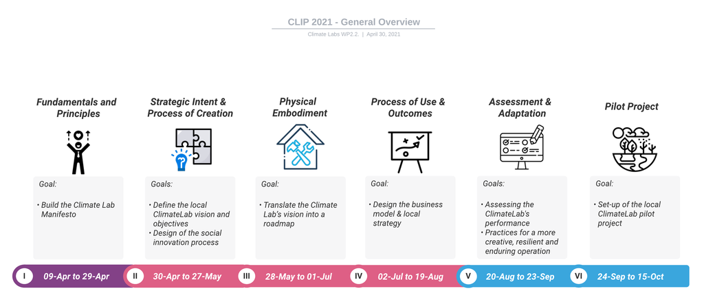

## Key Action Moments

There are five key action moments throughout the CLIP:

- **Sprint opening** (1h30 per sprint)
  - Synchronous webinar via Zoom in which sprint goals and main activities are presented to CLT
- **Online material** (Between 1h and 1h30 of video content per sprint)
  - CLT can access the online material via the CLIP website. Content is composed by conceptual videos, case experiences and complimentary readings
  - Members of CLT should access this content prior conducting each workshop
- **Team workshops** (Between 1h30 and 2h per workshop)
  - Each sprint proposes to the CLT a strategic workshop that should be conducted as a team
  - Workshops templates are provided via the Mural platform
- **Tutorships** (1h30 per sprint)
  - Intermediary check-ins via Zoom are proposed to the CLT in the forms of Q&A sessions
  - This is the moment for CLT to exchange with their mentors and guest experts to share their experiences or ask questions regarding the ongoing sprint’s goal.
- **Upload and share sprint results**
  - By the end of each sprint, the CLT should upload their workshop results to their Climate Lab website prototype
  - At the beginning of the next sprint, the CLT will briefly present to the consortium their results and learnings

> **Participants from each CLT are expected to dedicate 2 hours minimum per week to the CLIP.**

## Successful completion of the program

To successfully complete the incubation program, the CLT need to:

1. Conduct as a team each one of the workshops that will be assigned in each sprint.
2. Upload the workshop results to a non-published website that will constitute the prototype for the strategic design of their ClimateLab.
3. Share progress at the beginning of each sprint.
4. Final presentation of the strategic design of the Climate Lab at the mid-project meeting.

## Operation and online platforms

- All the incubation program content will be available through the **CLIP Website**: [<https://lf2l.fr/CLIP/>](https://lf2l.fr/CLIP/)
- Webinars and video calls will be held through **Zoom**.
- Workshop templates will be available via **MURAL**.
- Website prototype templates will be provided via **Google Sites**.

# Program Schedule

| **Sprint** | Object | **Goal(s)** | **Main Focus** |
| --- | --- | --- | --- |
| I | **Fundamentals & Principles** 3 weeks From 09/04/21 to 29/04/21 | - Build the Climate Lab Manifesto | - Set the stage in terms of Climate Change, Social Innovation and Innovation Lab - Teams focus on defining the CLT purpose |
| II | **Strategic Intent & Process of Creation** 4 weeks From 30/04/21 to 27/05/21 | - Define the Climate Lab’s vision and objectives - Design of the social innovation process | - The importance of building a collective strategic intent - Innovation labs facilitate innovation processes: what is the social innovation process for your Climate Lab? |
| III | **Physical Embodiment** 4 weeks From 28/05/21 to 01/07/21 | - Translate the Climate Lab’s vision into a technological resource roadmap | - Management of technological resources - Spaces to support social innovation |
| IV | **Process of Use & Outcomes** 6 8 weeks (including summer break) From 02/07/21 to 02/09/21 | - Design the business model & local strategy of the Climate Lab - To round out your Climate Lab’s strategic design and present your intent to all members of the Consortium | - The role of innovation labs in universities and climate change |
| V | **Assessment & Adaptation** 4 3 weeks From 03/09/21 to 23/09/21 | - Assess the Climate Lab performance | - Practices for a more creative, resilient and enduring operation |
| VI | **Pilot Project** 3 weeks From 24/09/21 to 15/10/21 | - Set-up of the local Climate Lab pilot project | - Moving from strategic to operational level: applying the living lab approach |

# CLIP Team

## Work-Package Leaders

- **Université de Lorraine**
  - Mauricio Camargo
  - Fabio Cruz
  - Ferney Osorio
  - Fanny Pruvot
- **Pontifícia Universidade Católica do Paraná**
  - André Turbay
  - Harry Bollmann

## Mentors

- **Universitat Politècnica de València**

**Carola Calabuig** PhD. Industrial Engineer by the Universitat Politècnica de València (UPV), she is full professor of the Department of Engineering Projects at the UPV and currently Academic Director of the Master’s Degree in Development Cooperation at the UPV, specializing in Project Management and Development Processes. Her main areas of work and interests are framed in development studies and include: development planning; international cooperation; sustainable development and critical approaches; democratic governance; education for development and global citizenship.

**Álvaro Fernández-Baldor** works at the Center for Development Cooperation of the Polytechnic University of Valencia (UPV - Spain), and is an associate professor in the Department of Engineering Projects of the UPV. He teaches in the Master of Development Cooperation of the UPV. He has done his PhD researching technological projects from the human development and capabilities approach. He also teaches as a guest lecturer in different fields, especially in cooperation masters in the areas related to engineering and development cooperation. He has field experience in Guatemala, Brazil, Peru and Kenya. In 2007 he received the first prize for the best final project in the IV PFC Competition in the field of technology for human development, for a design of an energy supply in an isolated rural area of Guatemala. In 2015 he has been awarded with the Doctoral Thesis Award for Development Cooperation of the Group-9 Universities.

- **Università di Genova**

Dr.-Ing. **Paola Alfaro d’Alençon** just started in February 2018 as a DFG-Research Fellow associated to the TU-Berlin, Faculty VI, Habitat Unit with the research project for the DFG: Concepts of Co-production and its influence on the development of inclusive spaces – An international comparative study on theories and practices”. She has 15 years of national and international work experience in research, education, knowledge transfer, and urban management and planning. These experiences are based on the topics of sustainable urban development associated with projects on housing (resilient development through interdisciplinary approaches linked to water management and local production chains, as well as through local solutions); governance, and co-production, with network development and stakeholder, cooperation management on urban and regional development strategies related to subjects of climate change, transport and mobility, and urban resilience.

- **Ashoka**

**Waldo Soto** is a commercial engineer from the Pontificia Universidad Católica de Chile with a Diploma in Innovation from Babson College, a Diploma in Global Management from University College London, and a MSc in Urban Management from Technical University Berlin. As Director of 2811, Waldo specialises in social innovation and sustainable urban development.

**Gabriela Carrasco** is director of 2811 and consultant for Ashoka in Latin America. MPA in Social Innovation and Impact Investment at NYU, Commercial Engineer and Political Scientist at the Catholic University of Chile. Contributing to the solution of the challenges of our region through the articulation of actors and the formation of agents of change.

## Tutorship Groups

**Groups of Universities**

**Mentoring Team**

**Group 1**

- Pontifícia Universidade Católica do Paraná
- Universidad del Quindio
- Instituto Tecnológico y Estudios Superiores de Monterrey

**Fabio Cruz**, Álvaro Fernández-Baldor, Gabriela Carrasco

**Group 2**

- Universidade Católica de Pernambuco
- Universidad de Caldas
- Universidad Tecnológica de Pereira

**Ferney Osorio**, Carola Calabuig, Harry Bollmann

**Group 3**

- Pontifícia Universidade Católica do Rio Grande do Sul
- Corporación Universitaria Minuto de Dios
- Universidad de Manizales
- Universidad de Guadalajara

**André Turbay,** Paola Alfaro, Waldo Soto

## Tutorship Schedule

All tutorship sessions will be held in parallel rooms via Zoom at 16h00 CET - 9:00am COL/MEX - 11:00am BRA

- Session 1 - 23/04/2021
- Session 2 - 14/05/2021
- Session 3 - 11/06/2021
- Session 4 - 09/07/21 27/08/2021 - Let’s test your pitch!
- Session 5 - 10/09/2021 - Present your pitch to the Climate Lab External Committee!
- Session 6 - 08/10/2021

# Prototyping your Climate Lab

## Colombia

In this link will be able to prototype your website :

- [Universidad de Caldas](https://sites.google.com/d/1pL3lPApfBU9OLEuKKYBZXeXeYRb-jaE-/p/1tui6PT_kfWJ98nbQqok9pOKUDlXlUtG5/edit)
- [Universidad del Quindio](https://sites.google.com/d/1CI-a9gJAyL9dL61FLLTkz73RuzQpgou8/p/1Bu6lxthfwOrrqB1COUU6-f5LhRk0Nsky/edit)
- [Universidad de Manizales](https://sites.google.com/d/1kdjgO68GGG1lxXVCX68pGhlEp1vYXeA4/p/1nyWSv7ycqrfRRE6af-KGqCkgAMEVzDeJ/edit)
- [Universidad Tecnológica de Pereira](https://sites.google.com/d/1QslfTrR0vOcFVcfr8wZORmnmSbUYcV7E/p/1CflzF0rmBMw7aXllbzIYBNuCU_JUm5fx/edit)
- [Corporacion Universitaria Minuto de Dios](https://sites.google.com/d/1H32GFcwa8C8TDTQm0AQ6sl8qUHLoYEj9/p/1PdDPvEV-SZTT-4_sUkm31ivHLdgbM86i/edit)

## Mexico

- [Instituto Tecnológico y Estudios Superiores de Monterrey](https://sites.google.com/d/1dMeeLPd_tg7iG4oPINaJayhs9rIJSQJ5/p/18_PamorFY22r801VlxNmpjn7Dmd1CPK8/edit)
- [Universidad de Guadalajara](https://sites.google.com/d/1bNgYjiqRrMmkxFDzChc_bZDVLmfB3fus/p/1_EaoX_ylap0XxTofXWHviR0CO1gVljDY/edit)

## Brazil

- [Pontifícia Universidade Católica do Rio Grande do Sul](https://sites.google.com/d/1-WzbtIVGZ67XJoQtYwsQQ4fJvTNcx6pf/p/16C-QvbueyFoDRZHUgU2Fulc25wb7MRAe/edit)
- [Pontifícia Universidade Católica do Paraná](https://sites.google.com/d/1aTVKN7wNbXqtU_Tu6FW67_HQcOpZPeVr/p/1CHQ1Nj_ANQFwBXjr7Nw9J8ssYHtdvoaX/edit)
- [Universidade Católica de Pernambuco](https://sites.google.com/d/1qetlenylpCIaKbvpU1inbQ-tDA23veFQ/p/16_ymcQrhMIBPApRC1Pj0wmoO3FxLQi5O/edit)

# Fundamentals and Principles

## Sprint Opening

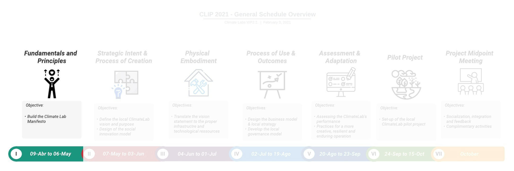

Welcome to the first sprint of the CLIP. Here we are going to focus con the Fundamentals and Principles for the Climate Labs.

**NOTICE!**

> The main goal in this sprint is to build your **Climate Lab Manifesto**

> *Sprint dates: **From April 9 to April 29***

A webinar will be held on April 9 to officially launch the incubation program. It will be a synchronous session, so all CLT are expected to attend. In addition, a series of contents and activities are proposed to the CLT to be completed during the sprint:

1. Firstly, you will find **three conceptual videos** which are proposed to open the discussion on the three thematic pillars that constitute the Climate Lab project: Climate Change, Social Innovation and Innovation Labs.
2. Secondly, **two case experiences** from members of the consortium are shared. This way we can learn a little more about the experience of each of the CLT.
3. Next, you will find the link to the **team workshop** of this sprint. The workshop should be completed before the end of the sprint (**April 29**).
4. And finally, **complementary readings** are offered for those who would like to further explore the topics addressed in this sprint.

**NOTICE!**

The [**full recording of the webinar** can be watched below. Alternatively, you can access the slides from the webinar here](https://drive.google.com/file/d/1d9LqoS8m5x47GpLhOdGzTJdwOGSDnFwj/view?usp=sharing).

[video not shown]

## Conceptual Videos

### Climate change and social challenges - Paola Alfaro d’Alençon & Harry Bollmann

[video not shown]

Professors Paola Alfaro d’Alençon from TU Berlin and Università di Genova, and Harry Bollman from Universidade Católica do Paraná have prepared a conversation around the mains aspects of climate change. Based on their experiences at their universities and the projects they have been involved in, Paola and Harry discuss climate change through different facets such as climate injustice, social infrastructure, governance and community. This video was edited with the best moments from the complete conversation, which can be accessed [here](https://www.youtube.com/embed/uO25jFtzatA).

### What is Social Innovation? - Gabriela Carrasco

[video not shown]

Gabriela Carrasco from Ashoka and 2811 shares an introduction to social innovation and entrepreneurship.

### Innovation Spaces - Laure Morel

[video not shown]

Professor Laure Morel from Université de Lorraine introduces the notion of innovation spaces and how these collaborative structures can play a major role in fostering social innovation for climate change. This presentation is based on her book chapter “Innovation spaces: new places for collective intelligence?” (Morel, Dupont, and Boudarel 2018).

## Case Experiences

### Universitat Politècnica de València

[video not shown]

Professor Carola Calabuig shares her experience and vision on social innovation at the INGENIO Research Institute of the Universitat Politècnica de València. She emphasizes the importance of the collective and grassroots dimension of innovation processes that happen outside the dominant or traditional spaces of knowledge generation.

### Universidad de Guadalajara

[video not shown]

Professor Javier Garcia of the Universidad de Guadalajara gives an overview of the project Carbon footprint measurement for the generation of sustainable strategies in avocado crops.

## Team Workshop 1

Here you can find for each University the link to the sprint 1 workshop:

## Colombia

- [Universidad de Caldas](https://app.mural.co/t/climatelabs8815/m/climatelabs8815/1616675648741/c2ce6b3dfa94dc38dbd1d84b626eb431b384b0ce)
- [Universidad del Quindio](https://app.mural.co/t/climatelabs8815/m/climatelabs8815/1616675741457/f922ea23c9660f9a14ac1c91ff7e89b7d0b3d080)
- [Universidad de Manizales](https://app.mural.co/t/climatelabs8815/m/climatelabs8815/1616675702123/dc11760127e13af1e59a5575681bda5cfe633597)
- [Universidad Tecnológica de Pereira](https://app.mural.co/t/climatelabs8815/m/climatelabs8815/1616675755540/5bc719c6f778fd04d56cea49018abe9625f58f33)
- [Corporacion Universitaria Minuto de Dios](https://app.mural.co/t/climatelabs8815/m/climatelabs8815/1616675729753/e52a7d6a35ef34d45facc76dd1954c84b6bb1899)

## Mexico

- [Instituto Tecnológico y Estudios Superiores de Monterrey](https://app.mural.co/t/climatelabs8815/m/climatelabs8815/1616675559523/b7b4daa571c961a087610e1ee45d23656f4478e1)
- [Universidad de Guadalajara](https://app.mural.co/t/climatelabs8815/m/climatelabs8815/1616675685168/778690af833bddde7f5defb515d485d9661f73ad)

## Brazil

- [Pontifícia Universidade Católica do Rio Grande do Sul](https://app.mural.co/t/climatelabs8815/m/climatelabs8815/1616675651832/fd916ddfef68c5a40ea5bb79c4f0180341392bb8)
- [Pontifícia Universidade Católica Do Paraná](https://app.mural.co/t/climatelabs8815/m/climatelabs8815/1616675588772/acac787fc9e21dc3995a307aff1cc2572f1422de)
- [Universidade Católica de Pernambuco](https://app.mural.co/t/climatelabs8815/m/climatelabs8815/1616675715846/7d87fc7bf493a5877d434f08c408d16de43a94f7)

## Let us know your comments

In this section, you can put any comments/questions or share your thoughts and feedback about this sprint. To insert new text, use the “Edit” button.

[interactive chart not shown]

# Strategic Intent & Process of Creation

## Sprint Opening

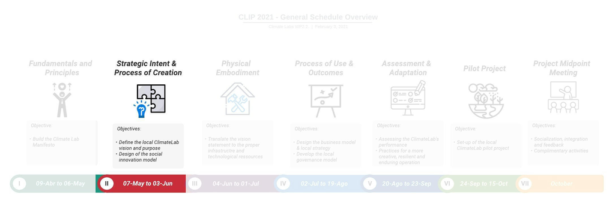

Welcome to the second sprint of the CLIP. In this sprint we are going to focus on the **Strategic Intent & Process of Creation** for the Climate Labs.

**GOAL**

This second sprint has two main goals:

> First, to define your **Climate Lab Vision**

> Second, to design the **Social Innovation Process** for your Climate Lab

> *Sprint dates: **From April 30 to May 27 / 2021***

A webinar will be held on **April 30** to officially launch the Sprint II. It will be a synchronous session, so all CLT are expected to attend. In addition, a series of contents and activities are proposed to the CLT to be completed during the course of the sprint:

1. Firstly, you will find a summary video of the **results from WP2.1**.
2. Secondly, **three conceptual videos** are proposed to open the discussion on the importance of defining a strategic intent for your Climate Lab and, further, to develop your own social design process as the methodological framework for your Climate Lab.
3. Thirdly, **two case experiences** from members of the consortium are shared. This way we can learn a little more about the experience of each of our partners.
4. Next, you will find the links to the **two (2) team workshops** of this sprint. The workshops should be completed before the end of the sprint (**May 27**).
5. And finally, **complementary readings** are suggested for those who would like to further explore the topics addressed in this sprint.

**NOTICE!**

The **full recording of the webinar** can be watched below.

[video not shown]

## Conceptual Videos

### Background on Strategic intent & Process of Creation

According to Moultrie et al. (2007), the design of an innovation environment “enables the development of unique capabilities, allows the reconfiguration of existing capabilities to changing demands, and supports synergies between complementary assets”. However, organizations rarely have explicit strategic goals underpinning the creation of their innovation lab initiatives. Instead, they often rely on single “champions” who are usually compelling sales persons whom believe passionately in the concept. Authors and practitioners agree that the existence of an underpinning strategic intent can prevent innovation labs or spaces to become vacuous spaces or merely innovation theaters with a superficial purpose.

Some of the commonly aspects to consider at the moment of defining the strategic intent of an innovation lab are (Osorio et al. 2019; Moultrie et al. 2007) :

Strategic Intent - Guiding set of criteria for Innovation Labs

| Criteria | Description |
| --- | --- |
| Strategic & Symbolic Goals | To support the mission of the organization or association innovation strategy |
| Ecosystem Approach | To generate added value for all the stakeholders involved, to create long-term engagement and identification with the lab. |
| Real Context World | To capture or resemble real life environments (through space, equipment or methodologies). |
| User’s Involvement | To involve users in the different phases of innovation cycle in which they can test, evaluate, contribute and co-create. |
| Culture and Community | To build an identity and to grow a community of users engaged and motivated with access to the laboratory. |
| Teamwork | To enhance teamwork in innovation, encouraging better communication (physical or virtual), encourage formal and informal social interaction and motivate staff. |
| Lifespan | To estimate the length of the project as a whole (short, mid or long-term). |

Beyond strategic reflection, it is also important to be aware of who will use the space and their needs, including the degree to which dedicated facilitation is required and ultimately, how the lab will be linked to the whole existing or desired innovation process (Magadley and Birdi 2009). Therefore, during the “process of creation”of an innovation lab one should be aware that, in practice, any work environment will evolve from the original intentions and will manifest the real work undertaken there.

Here we share with you some of the commonly aspects to take into account during the process of creation of an innovation lab (Osorio et al. 2019; Moultrie et al. 2007):

Process of Creation - Guiding set of criteria for Innovation Labs

| Criteria | Description |
| --- | --- |
| Intended Innovation Processes | The intended role of the lab in supporting innovation processes: Opportunity Identification, Concept Creation, Concept Validation, Solution Development, Solution Deployment |
| Intended Creative Activities | The intended role of the lab in supporting creative activities: Search, synthesis, creation, prototyping or evaluation. |
| Users and facilitators | The intended users of the space: from occasional test users or students through to dedicated environments for co-located project teams. The degree of dedicated facilitation that the lab is intended to… |
| Available resources & constraints | The availability of physical, financial, human and technical resources. |
| Intended events | The type of “events” that are expected to be held in the space, ranging from one-off meetings, marathons, conferences or project work |

### Summary of Results WP2.1 - Carola Calabuig

[video not shown]

Professor Carola Calabuig from the Universitat Politècnica de València presents the summary of the results of WP2.1 of the Climate Labs project. In this video she makes a review of the methodology used, a synthesis of the main results and finally some reflections and recommendations for the CLTs for the remainder of the project.

### Defining the Strategic Intent of your Climate Lab - Ferney Osorio

[video not shown]

Struggling at building and sustaining a collective intent among stakeholders is one of the main challenges for teams in charge of leading an innovation lab. In this video, Ferney Osorio from Université de Lorraine and Universidad Nacional de Colombia explains the concept of strategic intent, why it should be the cornerstone for the design and implementation of an innovation lab initiative and how can be used in the case of the Climate Labs. The content of this video is based on (Osorio et al. 2019) and (Mantere and Sillince 2007).

The Spanish version of this video can be accessed [here](https://youtu.be/_NyuXmCK8tA).

### Fab Living Lab: A collaborative innovation approach to support creative and sustainable territories - Laurent Dupont

[video not shown]

Laurent Dupont introduces the Lorraine Fab Living Lab® (LF2L) and how this platform supports collaborative innovation processes at the heart of the Université de Lorraine and the Grand Est Region in France. He develops the principles and motivations that led to the original conception of the Fab Living Lab approach, the framework on which the whole LF2L activity is orchestrated. To know more about this approach you can have a look to the paper (Dupont, Morel, and Pallot 2016).

### Applying the Fab Living Lab approach in the renovation of the Museum-Aquarium of Nancy - Giovanny Arbelaez

[video not shown]

Giovanny Arbelaez from Université de Lorraine gives a detailed example of the application of the Fab Living Lab Approach. In this case, Giovanny navigates the process of redesigning the museum experience by integrating interactive technologies supported by the Lorraine Fab Living Lab. To know more about this project you can have a look to the paper (Ten, Arbelaez-Garces, and Dupont 2020).

The Spanish version of this video can be accessed [here](https://youtu.be/M2Lfpbs1kxY).

## Case Experiences

### Pontifícia Universidade Católica do Rio Grande do Sul – Lucas Bonacina Roldan

[video not shown]

The Pontifícia Universidade Católica do Rio Grande do Sul presents us with a case of success in social innovation and climate change. Lucas Bonacina Roldan shows the PUCRS Service Learning Program that works to promote entrepreneurship and social innovation.

### Universidad del Quindío – Lina Marcela León & Faber Giraldo

[video not shown]

The Universidad del Quindío presents a case of success in mitigation and adaptation to climate change. Professors Faber Giraldo Velásquez and Lina Marcela León Gallón, researchers of the project, accompany us.

## Team Workshops 2 & 3

Here you can find for each University the links to **both workshops** for Sprint II:

## Colombia

- Universidad de Caldas: [Workshop 2](https://app.mural.co/t/climatelabs8815/m/climatelabs8815/1619705341808/e82167a6f0f5960dbd96be08905484dddc87b291) - [Workshop 3](https://app.mural.co/t/climatelabs8815/m/climatelabs8815/1619711397223/aedabd35e660a731537c23ed87153b7b9c497d43)
- Universidad del Quindio: [Workshop 2](https://app.mural.co/t/climatelabs8815/m/climatelabs8815/1619705526789/c4aaa9f44164c6834c183b02500fdf643b288f97) - [Workshop 3](https://app.mural.co/t/climatelabs8815/m/climatelabs8815/1619711465671/7b0679608129e7bf2b4f9673476cebbde49819b4)
- Universidad de Manizales: [Workshop 2](https://app.mural.co/t/climatelabs8815/m/climatelabs8815/1619705420379/7d1a6aea4fd21d2f48704a0bde13bb2a9e80ea6f) - [Workshop 3](https://app.mural.co/t/climatelabs8815/m/climatelabs8815/1616675702123/dc11760127e13af1e59a5575681bda5cfe633597)
- Universidad Tecnológica de Pereira: [Workshop 2](https://app.mural.co/t/climatelabs8815/m/climatelabs8815/1619705576971/33775405ca91ae9a6b47b957e4f096ee68de433e) - [Workshop 3](https://app.mural.co/t/climatelabs8815/m/climatelabs8815/1619711477192/c9f02735ab78ed2b2a3e5ca42907937ed3b14cfe)
- Corporacion Universitaria Minuto de Dios: [Workshop 2](https://app.mural.co/t/climatelabs8815/m/climatelabs8815/1619705472061/06d2d8810a0f5ff35f6f35a412f76ae8bb8b3906) - [Workshop 3](https://app.mural.co/t/climatelabs8815/m/climatelabs8815/1619711445654/a21b9433cac24f71982efc7d51c0ee959aa764d2)

## Mexico

- Instituto Tecnológico y Estudios Superiores de Monterrey: [Workshop 2](https://app.mural.co/t/climatelabs8815/m/climatelabs8815/1619705249525/8b04a7ef199eb383441807bd8a3515cacb5473df) - [Workshop 3](https://app.mural.co/t/climatelabs8815/m/climatelabs8815/1619711355218/77f43183879a19ae979a2bfa58ed7d87ca15f35e)
- Universidad de Guadalajara: [Workshop 2](https://app.mural.co/t/climatelabs8815/m/climatelabs8815/1619705388719/816625ed7554be41b2d5233973ae30fd7cf6b97b) - [Workshop 3](https://app.mural.co/t/climatelabs8815/m/climatelabs8815/1619711406901/14a5bbe75bcad9cf3901f058174571fb0838ea8e)

## Brazil

- Pontifícia Universidade Católica do Rio Grande do Sul: [Workshop 2](https://app.mural.co/t/climatelabs8815/m/climatelabs8815/1619705304500/351d81e359f5e183928e7fdfe01f165ffb6e96c4) - [Workshop 3](https://app.mural.co/t/climatelabs8815/m/climatelabs8815/1619711387682/6155f131455bacb56548dc8d4e102a61510dade0)
- Pontifícia Universidade Católica Do Paraná: [Workshop 2](https://app.mural.co/t/climatelabs8815/m/climatelabs8815/1619705272114/02b41f72cb8d7f09248892687d502d168d8d88b0) - [Workshop 3](https://app.mural.co/t/climatelabs8815/m/climatelabs8815/1619711378619/1e5eb619b110cfef182cd0aa7ffb49f3b03e8b5e?sender=u28f60cfd9c32927225640992)
- Universidade Católica de Pernambuco: [Workshop 2](https://app.mural.co/t/climatelabs8815/m/climatelabs8815/1619705446293/818a027141995bf57c4c53e7035f03fab31afde7) - [Workshop](https://app.mural.co/t/climatelabs8815/m/climatelabs8815/1619711435559/f515fff2b379d52b15302e3baae5d3043ae14579)

## Let us know your comments

In this section, you can put any comments/questions or share your thoughts and feedback about this sprint. To insert new text, use the “Edit” button.

[interactive chart not shown]

# Physical Embodiment

## Sprint Opening

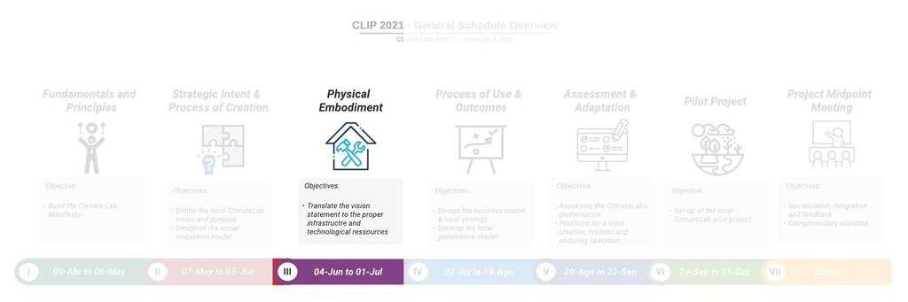

Welcome to the third sprint of the CLIP. In this sprint we are going to focus on the **Physical Embodiment** of the Climate Labs.

**GOAL**

The goal of the sprint 3 is:

> To translate the Climate Lab’s vision into a **technological resource roadmap**

> *Sprint dates: **From May 28 to July 1 / 2021***

A webinar will be held on **May 28** to officially launch the Sprint III. It will be a synchronous session, so all CLT are expected to attend. As usual, a series of content and activities are proposed to the CLT to be completed during the course of the sprint:

1. First, **three conceptual videos** are proposed to introduce the notion of technological resource management and, further, to have a wider view of the different manifestation of social innovation labs across the world.
2. Second, **two case experiences** from members of the consortium are shared. This way we can learn a little more about the experience of each of our partners.
3. Finally, you will find the link to the **team workshop** of this sprint. The workshop should be completed before the end of the sprint (**July 1**).

**NOTICE!**

The **full recording of the webinar** can be watched below.

[video not shown]

## Conceptual Videos

### Background on Physical Embodiment

The materialization of an innovation lab itself encompasses all the characteristics of the physical (or virtual) environment. The design of the space varies significantly, with different design values and degrees of flexibility; also, the way the space evolves needs to be contemplated. Different innovation labs contain diverse levels of physical resources, from IT infrastructure, support of prototyping and visualization to the furniture. Each setup is realized based on specific constraints such as resources, space, skills and time (Osorio et al. 2019). In this sense, one should always think about the physical embodiment of an innovation lab in terms of its use, creation and intentions. This means that a lab that seeks to foster teamwork should probably prioritize flexible workspaces and social areas, while another that aims to generate radical ideas may emphasize playfulness along with the provision of multiple sources of inspiration (Moultrie et al. 2007; Klooker et al. 2018).

The following are some of the aspects commonly considered to guide the physical embodiment of innovation labs (Osorio et al. 2019; Moultrie et al. 2007):

Physical Embodiment - Guiding set of criteria for Innovation Labs

| Criteria | Description |
| --- | --- |
| Geographic Location | The physical location of the environment and its relationship with the organization. This can include the organization’s own in-house space up to external third-party facilities. |
| Scale | The physical scale of the environment. |
| Real vs Virtual | The degree to which the space is designed around virtual teamwork and communication. |
| Flexibility | The degree of flexibility of the space to enable alternative configurations and uses. The degree of flexibility/reconfigurability of resources in the workspace. |
| Design Values | Specific design values targeted at encouraging specific behaviors. The use of imagery to reinforce actions. |
| IT Resources | The role of IT to enable group work, activities and processes. |
| Data & Information | The availability of local data/information to support innovation, creativity or design processes/activities. |
| Prototyping & Visualization | Availability of equipment, facilities and tools to support modeling and visualization activities as a core component of creative and design processes. |
| Constraints | Practical constraints on the design of the environment |
| Evolution | The degree to which evolution is planned to meet future goals. |

### Why to develop a Technological Strategy for our Climate Labs? - Mauricio Camargo

[video not shown]

Professor Mauricio Camargo from Université de Lorraine explains the concept of Management of Technological Resources as a means to identify the critical assets, capabilities and infrastructure for the sustainability of the Climate Labs. This prospective approach is instrumental in rapidly changing environments with a great deal of uncertainty. To know more about this approach you can have a look to the paper (Boly, Camargo, and Marche 2018; Marche, Boly, and Camargo 2017).

The Spanish version of this video can be accessed [here](https://youtu.be/fwIT1j5CcqQ).

### Supporting Social Innovation across the world - Mark Anderson

[video not shown]

Mark Majewsky Anderson, Director of Research and Innovation at Glasgow Caledonian University presents his perspective on social innovation in the university context. He also shares his experience in promoting the implementation of social support units in universities across Latin America, Asia and Europe.

### Implementing Innovation Spaces: The case of Hotmilk at PUCPR - Fernando Luciano & André Turbay

[video not shown]

In this video, Professor Fernando Luciano, Director of HotMilk the Innovation Ecosystem at PUCPR, discusses the conditions, challenges and concepts underlying the decision-making that led to the HotMilk space. We present this experience as a way to contribute ideas and possibilities for the ClimateLabs structures.

## Case Experiences

### Ashoka Mexico – Gabriela Carrasco

[video not shown]

Gabriela Carrasco from Ashoka Mexico presents the experience of the Social Innovation Center at the Universidad de Aysén in the Chilean Patagonia. This is one of the more than 40 university initiatives that have participated in Ashoka Commons, a program to accelerate university projects in social innovation.

### Instituto Tecnológico de Monterrey Campus Guadalajara – Sebastián Gradilla y Diego Díaz

[video not shown]

Professor Sebastián Gradilla and master’s student Diego Díaz of the Instituto Tecnológico de Monterrey Campus Guadalajara explain the role of the Sustainability and Climate Change Laboratory in addressing the challenges of agro-industrial waste management in the Jalisco region of Mexico.

## Team Workshop 4

Below you can find for each University the link to **workshop** for the Sprint III:

## Colombia

- Universidad de Caldas: [Workshop 4](https://app.mural.co/t/climatelabs8815/m/climatelabs8815/1622129003173/1f5dcf74fee58c4f142239b7031a6837d32b4de4?sender=u28f60cfd9c32927225640992)
- Universidad del Quindio: [Workshop 4](https://app.mural.co/t/climatelabs8815/m/climatelabs8815/1622129080275/5ce7acbe40a2c1ef4262ba8a8daf399af9de3651?sender=u28f60cfd9c32927225640992)
- Universidad de Manizales: [Workshop 4](https://app.mural.co/t/climatelabs8815/m/climatelabs8815/1622129031612/e21fc03d671f2fa15423ace284a1f0d7e2884b56?sender=u28f60cfd9c32927225640992)
- Universidad Tecnológica de Pereira: [Workshop 4](https://app.mural.co/t/climatelabs8815/m/climatelabs8815/1622129090631/ca119901854733fae0c6ba331b93ba4e96ad480e?sender=u28f60cfd9c32927225640992)
- Corporacion Universitaria Minuto de Dios: [Workshop 4](https://app.mural.co/t/climatelabs8815/m/climatelabs8815/1622129064729/18ee47f2deb4105574090e30c3aa35b7ff014887?sender=u28f60cfd9c32927225640992)

## Mexico

- Instituto Tecnológico y Estudios Superiores de Monterrey: [Workshop 4](https://app.mural.co/t/climatelabs8815/m/climatelabs8815/1622127710168/98c6c2e2dfe6088a5057d31846af32935cc52bd1?sender=u28f60cfd9c32927225640992)
- Universidad de Guadalajara: [Workshop 4](https://app.mural.co/t/climatelabs8815/m/climatelabs8815/1622129016833/0139920c7c5cd7d75866efc2e6d1d989bcfe5342?sender=u28f60cfd9c32927225640992)

## Brazil

- Pontifícia Universidade Católica do Rio Grande do Sul: [Workshop 4](https://app.mural.co/t/climatelabs8815/m/climatelabs8815/1622128511508/75a0c49b00856046ebb805404613d73a7ee72e77?sender=u28f60cfd9c32927225640992)
- Pontifícia Universidade Católica Do Paraná: [Workshop 4](https://app.mural.co/t/climatelabs8815/m/climatelabs8815/1622128398832/df1b33fe852c991dba55e400f444bf216ff408b8?sender=u28f60cfd9c32927225640992)
- Universidade Católica de Pernambuco: [Workshop 4](https://app.mural.co/t/climatelabs8815/m/climatelabs8815/1622129050815/3a294c99c347df2419ceb1e84c04623709fd5553?sender=u28f60cfd9c32927225640992)

## Let us know your comments

In this section, you can put any comments/questions or share your thoughts and feedback about this sprint. To insert new text, use the “Edit” button.

[interactive chart not shown]

# Process of Use & Outcomes

## Sprint Opening

This is the fourth sprint of the CLIP. Our attention now turns to the **Process of Use & Outcomes** of the Climate Labs.

**GOAL**

The goal of sprint IV is:

> To round out your Climate Lab’s strategic design and present your intent to all members of the Consortium.

> *Sprint dates: **From July 02 to September 02 / 2021***

**NOTICE!**

The **full recording of the webinar** can be watched below.

[video not shown]

## Conceptual Videos

### Background on Process of Use & Outcomes

Innovation labs are forced to adapt to the changing conditions and this may lead to new or adapted uses of the space. The way innovation is actually supported, which creative activities are done within the lab, or to what degree the space really enables teamwork are some of the elements to take into consideration. But more importantly is to be sensitive to compare how much this has changed in comparison to the original intent and the process of creation. Being flexible but tracking those changes could lead to helpful insights to understand the role the lab.

The following are some of the aspects that should guide the process of use of an innovation lab (Osorio et al. 2019; Moultrie et al. 2007):

Process of Use - Guiding set of criteria for Innovation Labs

| Criteria | Description |
| --- | --- |
| Supporting Innovation | The stage(s) of the innovation process in which the lab is actually used |
| Supporting Creativity | The way in which the lab effectively supports creative activities |
| Actual users & facilitators | The actual users that are welcome in the space. The actual degree of facilitation required for the activities conducted in/by the lab |
| Enabling teamwork | The actual role of the space in enabling physical and virtual teamwork |
| Actual events | The type of events that actually take place in the lab |

Referring to innovation labs, it is naturally expected that their activity will result in some kind of innovation output. However, due to their intermediate nature, their results are not always easy to recognize or value. Beyond this, it is clear that the activity of innovation labs triggers a set of creative and innovation processes involving the community that ultimately lead to positive testimonials and compelling stories. Therefore, when referring to the outcomes of an innovation lab one should consider both its tangible and intangible results that are duplicable, new and useful in its context (Osorio et al. 2019; Moultrie et al. 2007).

Outcomes - Guiding set of criteria for Innovation Labs

| Criteria |
| --- |
| Tangible results |
| Intangible results |
| Realization of strategic intent |

### The Green FabLab Project - Fabio Cruz

[video not shown]

Fabio Cruz, research associate at the University of Lorraine presents the case of Green FabLab, a research project dedicated to the creation of a local and open source plastic recycling process for a circular economy. To know more about this project you can have a look to the paper (Roux-Marchand et al. 2020).

### LabCidades: The Community Garden - Rafael Camargo & André Turbay

[video not shown]

The Community Garden brought together several actors from the neighborhood that includes PUCPR. From the dream of a resident of the neighborhood, to transform an area that served as a waste deposit into a space that would contribute to the community. As a result of this initiative, several actors were connected, such as a local daycare center, collectors of recyclables, and the PUCPR itself, through LabCidades and the Curos de Agronomia. This video explains how this transformation took place.

## Case Experience

### Université de Lorraine – Mauricio Camargo

[video not shown]

Professor Mauricio Camargo, Director of the Research Institute for Research in Innovation Processes - ERPI and Professor at the School of Innovation - ENSGSI explains the role of the Lorraine Fab Living Lab - LF2L at the Université de Lorraine.

## Team Workshop 5 - Pitch your Climate Lab to your peers!

The purpose of this workshop is for you to round-up the strategic design of your Climate Lab and be ready to communicate your intent to your partners and stakeholders. Therefore, the main task for you during this fourth sprint is to prepare a pitch to present your Climate Lab in 3 minutes. The following are the main steps that we are going to follow:

1. **Prepare your pitch!**
   - Round-up the strategic design of your Climate Labs. This means that you should have finished all the precedents workshops so you can have all the insights to feed your pitch.
   - Based on all the previous work, collectively identify your value, your ambition, your strengths and your expected tangible and intangible results (environmental impact, social impact…).
   - Any pitch must be tailored to the audience. Identify what emotions you want to generate: (i) create a connection with your audience to establish shared values or build communion, (ii) foster collaboration by getting the audience to take action or side with you, or (iii) generate awareness through education and be informative.
2. **Let’s test your pitch!**
   - During the mentoring session (August 27) each one of the CLT will present their Climate Lab to all members of consortium.
   - You will receive feedback from mentors and all the Climate Lab community.
3. **Present your pitch to the Climate Lab External Committee!**
   - Reflect on the feedback received from your peers and adjust your pitch
   - A special event is being prepared for the opening of Sprint 5 (September 10) where all CLT are invited to present their Climate Lab in 3 minutes to the External Committee. Be ready!

Here we share with you some tips for making an impactful pitch:

- Identify what type of pitch you want to use. You can mix types, but be as clear as possible.
  - **Tweet Pitch:** respond to the questions: What? How? Why? answer a question: what does the Climate Lab do?
  - **Pitch to investors:** have a structure with key elements, why they are going to leave their money in your lab.
  - **Pitch to partners:** present the purpose of your lab, show what are the advantages of collaborating with your lab. Ask all team members why they want to work on this climate lab project.
  - **Sales pitch:** convince your potential clients to trust in your lab initiative, to participate in it. Present how your Climate Lab will be useful in their life.
- Find 10 words that best represent your Climate Lab. Choose 10 words that you think are the most meaningful to share about your lab.
- The key part of a speech:
  - The first sentence of a pitch is the most important. It must grab attention and the audience must understand the purpose of your project.
  - Identify what problem you are going to address. State the emotions associated with that problem.
  - Present the results and what you will do in your lab.
- Finally, training is extremely important. Your pitch will become clearer with practice.

*Tips based on:*

- *Morlet, C. & Deloupy, B. (2018). Outil 11. Générez un impact en deux minutes : le pitch. Dans : , C. Morlet & B. Deloupy (Dir), La boîte à outils du Speaker-Conférencier (pp. 44-47). Paris: Dunod.*
- *Morgan, W. R., & Wright, E. S. (2021). Ten simple rules for hitting a home run with your elevator pitch. PLoS Computational Biology, 17(3), 1–5. https://doi.org/10.1371/JOURNAL.PCBI.1008756*
- *EF Venturas, (2021) Aprende cómo construir un pitch ganador*

# Assessment & Adaptation

## Sprint Opening

This is the fifth sprint of the CLIP. Here the attention turns to the **Assessment & Adaptation** of the Climate Labs.

**GOAL**

The goal of sprint V is:

> To present your Climate Lab’s strategic design in a 3-minute pitch to the members of the External Committee.

> *Sprint dates: **From September 03 to September 23 / 2021***

In this sprint the Climate Lab Teams will be focused on adjusting their pitch for the presentation to the External Committee of the Climate Lab Project. This session will be held on **September 10** and all the CLT will have the opportunity to present their strategic design in 3 minutes followed by a feedback exchange. This is a synchronous session, so all CLT are expected to attend. As usual, a series of content and activities are proposed to the CLT to be completed during the course of the sprint:

1. In this opportunity **two conceptual videos** are proposed to shared the experience of two university-hosted innovation lab in Chile and Colombia.
2. Then, the **team workshop** section which this time is dedicated to the pitch presentation and the subsequent refinement and finalization of each Climate Lab’s website prototype.

## Conceptual Videos

### Background on Assessment & Adaptation

Designing, managing and sustaining a social innovation lab is a challenging task. Many established innovation lab initiatives are future-oriented in terms of being conceived to demonstrate “new ways of doing things”. However, what seems futuristic today may become obsolete with the fast pace of socio-technological advances. This means that innovation lab teams will probably have to reinvent themselves by introducing new methods, practices or technologies, as well as reconfiguring their configuration or even redefining their purpose (Rayna and Striukova 2019; Magadley and Birdi 2009; Osorio et al. 2020). This also implies that lab teams need to be aware of developing feedback tools and processes so this continuous reinvention can occur. The methodological framework that guided this incubation program - Strategic Intent, Process of Creation, Physical Embodiment, Process of Use and Outcomes- is proposed as an strategic tool for lab managers and lab teams, not only to define the innovation lab intent, but also to track of what is happening and enable adaptation and strategy redefinition.

Innovation Lab Framework Outline (Moultrie et al. 2007; Osorio et al. 2019)

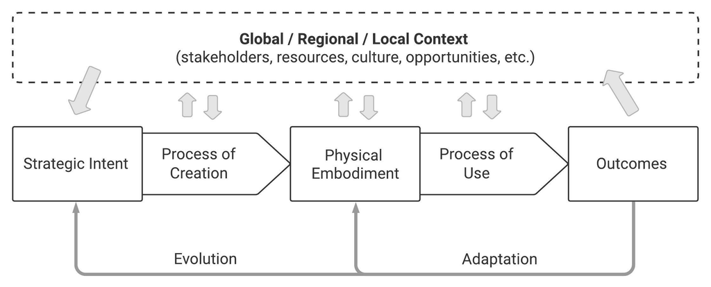

We encourage you to keep this incubation program in mind not just as a series of one-time tasks, but as an iterative process that you can repeat periodically and collectively to track your lab’s progress. This will help engage stakeholders to continue to support your Climate Lab initiative.

### Innovation labs in Universities: The case of the LEIND - Lorena Delgado

[video not shown]

Lorena Delgado explains the contribution that an innovation lab can make to Latin American universities. She does so by presenting her experience with the Entrepreneurship and Innovation Laboratory -LEIND- at the Universidad de Santiago de Chile. To know more about how the LEIND supports collaborative learning please refer to (Delgado et al. 2020).

### Shaping an Innovation Lab through time, space and stakeholders - Ferney Osorio

[video not shown]

In this video, Ferney Osorio from Université de Lorriane and Universidad Nacional de Colombia explains the challenges of operating an innovation lab. For this, he presents the case of the ViveLab Bogotá, one of the first public innovation labs in Colombia (today it is called Lab101). The evolution and main outcomes from this initiative are presented using the methodological framework that guided the incubation program. To know more about this case and the theoretical foundations of this work you can refer to (Osorio et al. 2020).

## Team Workshop 6 - Pitch your Climate Lab and Wrap-up of your website prototype!

The purpose of this workshop is for you to round-up the strategic design of your Climate Lab and be ready to communicate your intent to your partners and stakeholders. Therefore, the main task for you during the fifth sprint is to to refine and present your Climate Lab to the external committee. The following are the main steps that we are going to follow:

1. **Present your pitch to the Climate Lab External Committee!**
   - Reflect on the feedback received from your peers and adjust your pitch
   - A special event is being prepared for (September 10) where all CLT are invited to present their Climate Lab in 3 minutes to the External Committee. Be ready!

**NOTICE!**

The **full recording of the pitch training session (August 27)** can be watched below.

[video not shown]

[video not shown]

2. **Don’t forget to complete your website prototype!**
   - CLTs are reminded to complete the website prototype based on the results of each of the sprints. Remember that this is a support tool for you to have a clean version of your strategic design and also to communicate your intent and results. As we are entering to the final stage of the incubation program, CLTs are invited to complete their website by the end of this sprint (September 23).

# Pilot Project

## Sprint Opening

This is the last sprint of the CLIP. This sprint is a transition from the incubation program to the implementation of the **Pilot Project** of each Climate Lab.

**GOAL**

> To set-up the local Climate Lab pilot project moving from the strategic to the operational level.

> *Sprint dates: **From September 24 to October 15 / 2021***

In this sprint the Climate Lab Teams will focus their efforts on the set-up of their pilot project. In this case leaders from the Work Package 2.4 join us to provide the introduce the methodology that will guide the pilot project implementation. Specifically for this sprint, the teams are invited to assess their territory and community.

1. For this sprint **the last two conceptual videos** share insights on the application of the living lab approach. This approach/methodology is considered suitable to the pilot projects.
2. Then, the final **team workshop** is proposed by the colleagues from Work Package 2.4 during the opening webinar.

**NOTICE!**

The **full recording of the webinar** can be watched below.

[video not shown]

## Conceptual Videos

### Living Lab approach applied to French forestry policy priorities - Maxence Arnould

[video not shown]

Maxence Arnould, from the University of Lorraine, shares his experience and insights on the application of the Living Lab approach to increase the commitment of private forest owners in French forest policy priorities. To know more about this case and the theoretical foundations of this work you can refer to (Arnould, Morel, and Fournier 2021).

### The Linky by Makers project: A Fab Living Lab Project - Laurent Dupont

[video not shown]

Laurent Dupont from Université de Lorraine shares in this video the Linky by Makers project as a new form of collaboration between Makers or FabLabs , Academics and Companies. By Sharing ideas and pooling resources, Linky by Makers sought to prototype citizen solutions for “Smart Grid” deployment. To know more about this project you can have a look to the paper (Dupont et al. 2019).

# Acknowledgments

The Climate Lab Incubation Program constitutes an original work that comes from the valuable contribution from multiple people and institutions. In these few lines we would like to acknowledge and thank them for their time and support.

- To Laure Morel, Laurent Dupont, Giovanny Arbelaez and Maxence Arnould from ENSGSI School and the ERPI Laboratory of Université de Lorraine for contributing their knowledge and research experience to this program
- To the student association GSI Media from the ENSGSI School for their support in editing the conceptual videos
- To Valeria Gonzalez and the Universidad de Caldas for producing and editing the case experience videos
- To Lorena Delgado and the Universidad Santiago de Chile for sharing the journey of their innovation lab the LEIND
- To Mark Andersson and the Glasgow Caledonian University for presenting their experience in supporting social innovation initiatives around the world
- To Paola Alfaro d’Alençon from TU Berlin and Università di Genova for her participation in the conversation around Climate Change
- To Gabriela Carrasco and Waldo Soto of Ashoka and 2811 for bringing their expertise in Social Entrepreneurship and Innovation and their valuable feedback in structuring this incubation program
- To all the members of the Climate Lab Consortium for contributing to case experience videos

# References

Arnould, Maxence, Laure Morel, and Meriem Fournier. 2021. “Developing the Persona Method to Increase the Commitment of Non-Industrial Private Forest Owners in French Forest Policy Priorities.” *Forest Policy and Economics* 126 (May): 102425. https://doi.org/10.1016/j.forpol.2021.102425.

Boly, Vincent, Mauricio Camargo, and Brunelle Marche. 2018. “Stratégie Technologique Et Processus d’innovation - Une Méthode Pour Les Coordonner.” *Ref : TIP452WEB - "Opérations Unitaires. Génie de La Réaction Chimique"*, May. https://www.techniques-ingenieur.fr/base-documentaire/procedes-chimie-bio-agro-th2/innovations-en-genie-des-procedes-42487210/strategie-technologique-et-processus-d-innovation-j8125/.

Delgado, Lorena, Daniel Galvez, Alaa Hassan, Pedro Palominos, and Laure Morel. 2020. “Innovation Spaces in Universities: Support for Collaborative Learning.” *Journal of Innovation Economics & Management* n°31 (1): 123. https://doi.org/10.3917/jie.pr1.0064.

Dupont, Laurent, Joëlle Mastelic, Nathalie Nyffeler, Sophie Latrille, and Eric Seulliet. 2019. “Living lab as a support to trust for co-creation of value: application to the consumer energy market.” *Journal of Innovation Economics* 28 (1): 53. https://doi.org/10.3917/jie.028.0053.

Dupont, Laurent, Laure Morel, and Marc Pallot. 2016. “2016 International Conference on Engineering, Technology and Innovation/IEEE Lnternational Technology Management Conference (ICE/ITMC.” In. IEEE. https://doi.org/10.1109/ice/itmc39735.2016.9025965.

Klooker, Marie, Martin Schwemmle, Claudia Nicolai, and Ulrich Weinberg. 2018. “Making Use of Innovation Spaces: Towards a Framework of Strategizing Spatial Interventions.” In, 75–96. Springer International Publishing. https://doi.org/10.1007/978-3-319-97082-0_5.

Magadley, Wissam, and Kamal Birdi. 2009. “Innovation Labs: An Examination into the Use of Physical Spaces to Enhance Organizational Creativity.” *Creativity and Innovation Management* 18 (4): 315–25. https://doi.org/10.1111/j.1467-8691.2009.00540.x.

Mantere, Saku, and John A.A. Sillince. 2007. “Strategic Intent as a Rhetorical Device.” *Scandinavian Journal of Management* 23 (4): 406–23. https://doi.org/10.1016/j.scaman.2007.03.002.

Marche, Brunelle, Vincent Boly, and Mauricio Camargo. 2017. “Integration of Technology Management, Prospective and Innovation Strategy: The Case of a Luminaire Manufacturer.” In *IAMOT*. https://hal.archives-ouvertes.fr/hal-01891048/.

Morel, Laure, Laurent Dupont, and Marie-Reine Boudarel. 2018. “Innovation Spaces: New Places for Collective Intelligence?” In, 87–107. John Wiley & Sons, Inc. https://doi.org/10.1002/9781119557883.ch5.

Moultrie, James, Mikael Nilsson, Marcel Dissel, Udo-Ernst Ernst Haner, Sebastiaan Janssen, and Remko Van der Lugt. 2007. “Innovation Spaces: Towards a Framework for Understanding the Role of the Physical Environment in Innovation.” *Creat. Innov. Manag.* 16 (1): 53–65. https://doi.org/10.1111/j.1467-8691.2007.00419.x.

Osorio, Ferney, Laurent Dupont, Mauricio Camargo, Pedro Palominos, José Ismael Peña, and Miguel Alfaro. 2019. “Design and Management of Innovation Laboratories: Toward a Performance Assessment Tool.” *Creativity and Innovation Management* 28 (1): 82–100. https://doi.org/10.1111/caim.12301.

Osorio, Ferney, Laurent Dupont, Mauricio Camargo, Carlos Sandoval, and José Ismael Peña. 2020. “Shaping a Public Innovation Laboratory in Bogota: Learning through Time, Space and Stakeholders.” *Journal of Innovation Economics & Management* n°31 (1): 69. https://doi.org/10.3917/jie.pr1.0066.

Rayna, Thierry, and Ludmila Striukova. 2019. “Open Social Innovation Dynamics and Impact: Exploratory Study of a Fab Lab Network.” *R&D Management* 49 (3): 383–95. https://doi.org/10.1111/radm.12376.

Roux-Marchand, Thibaut, Fabio Cruz, Laurent Dupont, Mauricio Camargo, and Ferney Osorio. 2020. “2020 IEEE International Conference on Engineering, Technology and Innovation (ICE/ITMC).” In. IEEE. https://doi.org/10.1109/ice/itmc49519.2020.9198320.

Ten, Ievgeniia, Giovanny Arbelaez-Garces, and Laurent Dupont. 2020. “2020 IEEE International Conference on Engineering, Technology and Innovation (ICE/ITMC).” In. IEEE. https://doi.org/10.1109/ice/itmc49519.2020.9198641.

[^1]: https://erpi.univ-lorraine.fr/
[^2]: https://www.pucpr.br/